# Timing machine

## Input generator

Define an algorithm to be tested, for now just the default distance estimation from `igraph`:

```r
algoDistances <- function(g, params) {  # params will be passed by Timing Machine, ignored for now
  require(igraph)
  average.path.length(g)
}
```

Function call from C:

```r
library(Rcpp)
sourceCpp(here("src", "bfs_from_R.cpp"))
algoCDistances <- function(g, params) {
  # g must be an adjacency list here. No params taken
    Cbfs_list(g)
}
adjListFromDistr <- function(size, distr){
  g <- graphFromDist(size, distr)
  g2  <- g %>% as_adj_list %>% lapply(function(x) as.vector(x-1))
  attr(g2, 'nodes') <- gorder(g)
  attr(g2, 'edges') <- gsize(g)
  g2
}
```

## Run series of sizes

Specyfying a range of input sizes we can obtain runtimes of the algorithm with a single function call:

```r
sizes <- seq(200, to = 5000, by = 200)
```

The same series on C algorithm:

```r
     # to be automated, use precomputed values if available
  resC <- runOnSizes(algoCDistances, adjListFromDistr,
                  sizes, 300,
                  inputArgs = dfit, algArgs = c())
```

Run series on standard `igraph` algorithm:

```r
     # to be automated, use precomputed values if available
  res <- runOnSizes(algoDistances, graphFromDist,
                  sizes, 300,
                  inputArgs = dfit, algArgs = c())
```

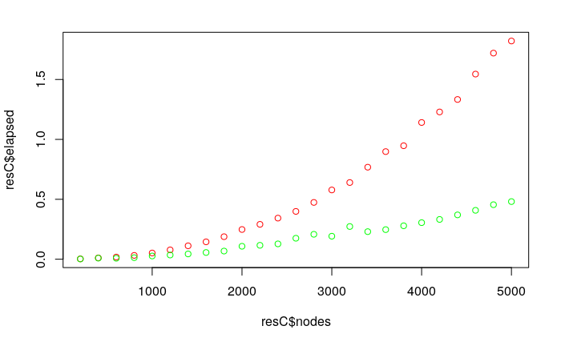

```r
{plot(resC$nodes, resC$elapsed, col="red")
points(res$nodes, res$elapsed, col="green")}
```

Having gathered enough datapoints one can fit a linear model and asses visually how it matches the data:

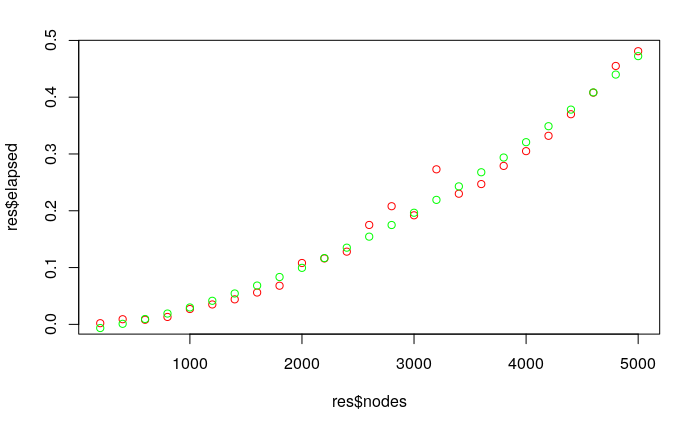

```r
squarefit <- lm(elapsed ~ poly(nodes, 2), data = res)
# plot(squarefit)
{ plot(res$nodes, res$elapsed, col="red")
  points(res$nodes, predict(squarefit, res), col="green")}
```

And also inspect parameters of the model and various measures of it’s uncertainity:

```r
summary(squarefit)
```

```
Call:
lm(formula = elapsed ~ poly(nodes, 2), data = res)

Residuals:
      Min        1Q    Median        3Q       Max
-0.020801 -0.012286 -0.004500  0.008513  0.053823

Coefficients:
                Estimate Std. Error t value Pr(>|t|)
(Intercept)     0.182760   0.003568  51.228  < 2e-16 ***
poly(nodes, 2)1 0.719363   0.017838  40.328  < 2e-16 ***
poly(nodes, 2)2 0.126449   0.017838   7.089 4.13e-07 ***
---
Signif. codes:  0 ‘***’ 0.001 ‘**’ 0.01 ‘*’ 0.05 ‘.’ 0.1 ‘ ’ 1

Residual standard error: 0.01784 on 22 degrees of freedom
Multiple R-squared:  0.987, Adjusted R-squared:  0.9859
F-statistic: 838.3 on 2 and 22 DF,  p-value: < 2.2e-16
```

Note that in order to protect the model from correlation between powers of `nodes`, orthogonal polynomials are used. The `poly` function returns uncorrelated and normalised columns corressponding to consecutive powers of it’s first argument.

As the model seems to fit our observations, we may try to extrapolate execution time of the same algorithm with a bigger input size:

```r
bigsizes <- seq(6000, to=12000, by=2000)
bigres <- runOnSizes(algoDistances, graphFromDist,
                    bigsizes, 150,
                    inputArgs = dfit, algArgs = c())
```

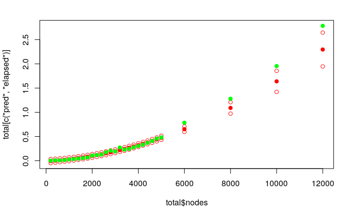

```r
total <- rbind(res, bigres)
total$pred <- predict(squarefit, newdata = total, interval = "prediction")
matplot(total$nodes, total[c("pred", "elapsed")], col = c("red", "red", "red", "green"), pch = c(19, 1, 1, 19))
```

It comes out the prediction is a bit undershot but catches nonlinear behaviour of the data.